# Damrong's Simple Teleop

## Set up

This project has been tested on Ubuntu 24.04.3 LTS.

Please verify that we have a directory named `teleop` (or any name) that contain these files:

```
$ ls -RF teleop/
teleop/:
DamrongAsset/  Damrong_teleop.ipynb

teleop/DamrongAsset:
asset/  DamrongAsset_package.xml

teleop/DamrongAsset/asset:
manipuland/  scene/

teleop/DamrongAsset/asset/manipuland:
cuboid.obj  cuboid.sdf  cuboid.stl  cuboid.vtk  peg.obj  peg.sdf  peg.stl  peg.vtk

teleop/DamrongAsset/asset/scene:
Damrong_peg_cuboid.dmd.yaml
```

Please follow these steps to set up the teleop simulation.

1. Create a virtual environment in a subdirectory, say `venv`.

```
teleop $ mkdir venv
teleop $ python3 -m venv venv
teleop $ source venv/bin/activate
```

The prompt will have `(venv)`. This is important because we don't want this project to change the existing Python environment on the computer yet.

```
(venv) teleop $
```

2. Install the `manipulation` package with the nightly `Drake` build (or any specific version) in the virtual environment. Please be patient. It might download a few gigabytes.

```
(venv) teleop $ pip install manipulation[all] --extra-index-url https://drake-packages.csail.mit.edu/whl/nightly/
```

3. Install the notebook package.

```
(venv) teleop $ pip install notebook
```

4. Run this notebook.

```
(venv) jupyter notebook
```

You should see `Damrong_teleop.ipynb` (a copy of this file) in the list. Open it.

5. Change `DamrongAsset_package_xml` in the following cell to the appropriate path.

```python
# Change to where you store the asset files.
DamrongAsset_pacakge_xml = "/home/damrongguoy/project/teleop/DamrongAsset/DamrongAsset_package.xml"
```

## Dependency

```python
import matplotlib.pyplot as plt
import time
import numpy as np

from functools import partial
from IPython.display import Code
from pathlib import Path

from pydrake.geometry import StartMeshcat
from pydrake.multibody.inverse_kinematics import (
    DifferentialInverseKinematicsParameters,
    DifferentialInverseKinematicsStatus,
    DoDifferentialInverseKinematics,
)
from pydrake.systems.analysis import Simulator
from pydrake.systems.framework import DiagramBuilder, EventStatus, LeafSystem
from pydrake.visualization import MeshcatPoseSliders

from pydrake.all import (
    BasicVector,
    CalcSpatialInertia,
    ContactResults,
    Context,
    GeometryId,
    Role,
    LogVectorOutput,
    PackageMap,
    ReadObjToTriangleSurfaceMesh,
    Value
)

from manipulation.meshcat_utils import StopButton, WsgButton
from manipulation.station import LoadScenario, MakeHardwareStation, MakeMultibodyPlant
from manipulation.systems import AddIiwaDifferentialIK, MultibodyPositionToBodyPose
from manipulation.utils import RenderDiagram
```

# Preliminary: Generate and Verify Assets

I started from the given .stl files:

```
DamrongAsset/asset/manipuland/cuboid.stl
DamrongAsset/asset/manipuland/peg.stl
```

I created their compatible assets (.obj, .vtk, .sdf) for the hydroelastic contact model:

```
DamrongAsset/asset/manipuland/cuboid.obj
DamrongAsset/asset/manipuland/cuboid.vtk
DamrongAsset/asset/manipuland/cuboid.sdf

DamrongAsset/asset/manipuland/peg.obj
DamrongAsset/asset/manipuland/peg.vtk
DamrongAsset/asset/manipuland/peg.sdf
```

The hydroelastic contact model needs a collision geometry represented as a tetrahedral mesh in a VTK file. The following document explains how to generate an appropriate tetrahedral mesh from a surface mesh in STL or OBJ format.

https://docs.google.com/document/d/1VZtVsxIjOLKvgQ8SNSrF6PtWuPW5z9PP7-dQuxfmqpc/edit?usp=sharing

For visual geometry, Drake prefers an OBJ file. The above document also describes one way to convert STL to OBJ.

### (TODO) Explain the need for mesh refinement (on surface and inside volume)

### (TODO) Explain how to package new asset files for PackageMap

### (TODO) Explain how to set proximity properties in SDFormat files

### Verify Inertia Tensor

A common problem is the incorrect inertia tensor specified in the description file, which contaminates the solution of the governing equations.

The code below will calculate the inertia matrix from the mesh. It is a simplified and customized version of this [snippet](https://github.com/DamrongGuoy/drake/blob/3117d1787a694e91c4723b14d445b1079be799e9/bindings/pydrake/multibody/_mesh_model_maker.py#L152-L245) in drake/bindings/pydrake/multibody/_mesh_model_maker.py.

Later we will use this calculation to verify the content in the .sdf files.

```python
def CalculateInertiaMatrixFromDamrongMesh(package_path_to_asset_prefix, mass_density):
    package_map = PackageMap()
    package_map.AddPackageXml(DamrongAsset_pacakge_xml)
    obj_path = package_map.ResolveUrl(package_path_to_asset_prefix+".obj")

    print()
    print(obj_path)
    print(f"Input mass density: {mass_density} kg/m^3")

    # The OBJ file uses millimeters. Convert to meters.
    mesh_scale = 0.001
    surface_mesh = ReadObjToTriangleSurfaceMesh(filename = obj_path, scale = mesh_scale)

    # G = the expressed-in frame of the object.
    mesh_G = surface_mesh
    p_GoMin, p_GoMax = mesh_G.CalcBoundingBox()
    size = p_GoMax - p_GoMin
    print(f"Size of bounding box in meters (scaled mm to m): {size[0]} x {size[1]} x {size[2]} meters")

    # This calculation is relative to the origin of the coordinate
    # frame of the mesh, which may or may not coincide with the
    # center of mass, depending on the shape of the object.
    M_GGo_G = CalcSpatialInertia(mesh = mesh_G, density = mass_density)
    mass = M_GGo_G.get_mass()
    volume = mass / mass_density
    p_GoGcm = M_GGo_G.get_com()
    print(f"Mass: {mass} kg")
    print(f"Volume: {volume} cubic meters")
    print(f"Center of mass (p_GoGcm): [{p_GoGcm[0]}, {p_GoGcm[1]}, {p_GoGcm[2]}]")

    # Shift the matrix tensor to the center of mass.
    M_GGcm_G = M_GGo_G.Shift(p_GoGcm)

    # Now we can calculate relative to the center of mass.
    I_GGcm_G = M_GGcm_G.CalcRotationalInertia()
    moments = I_GGcm_G.get_moments()
    products = I_GGcm_G.get_products()

    subs = dict()
    p_GoGcm_str = " ".join([str(x) for x in p_GoGcm])
    subs["inertial_pose"] = f"{p_GoGcm_str} 0 0 0"
    subs["mass"] = mass
    subs["ixx"] = moments[0]
    subs["iyy"] = moments[1]
    subs["izz"] = moments[2]
    subs["ixy"] = products[0]
    subs["ixz"] = products[1]
    subs["iyz"] = products[2]
    subs["mesh_scale"] = "{s} {s} {s}".format(s = mesh_scale)
    subs["package_path_to_asset_prefix"] = package_path_to_asset_prefix

    _SDF_TEMPLATE = """
          <inertial>
            <pose>{inertial_pose}</pose>
            <mass>{mass}</mass>
            <inertia>
              <ixx>{ixx}</ixx> <ixy>{ixy}</ixy> <ixz>{ixz}</ixz>
              <iyy>{iyy}</iyy> <iyz>{iyz}</iyz>
              <izz>{izz}</izz>
            </inertia>
          </inertial>
          <visual name="visual">
            <geometry>
              <mesh>
                <uri>{package_path_to_asset_prefix}.obj</uri>
                <scale>{mesh_scale}</scale>
              </mesh>
            </geometry>
          </visual>
          <collision name="collision">
            <geometry>
              <mesh>
                <uri>{package_path_to_asset_prefix}.vtk</uri>
                <scale>{mesh_scale}</scale>
              </mesh>
            </geometry>
    """

    print(_SDF_TEMPLATE.format(**subs))
    print("Don't forget mesh scale: <scale>", subs["mesh_scale"], "</scale>")
    print()
```

### Verify the cuboid

For simplicity, we use 950 kg/m^3 (HDPE) for both the cuboid and the peg.

#### Please make sure the result from CalculateInertiaMatrixFromDamrongMesh() matches the .sdf file.

```python
CalculateInertiaMatrixFromDamrongMesh(
    "package://DamrongAsset/asset/manipuland/cuboid",
    950,
)

def ReadFileFromUrl(url, package_xml):
    package_map = PackageMap()
    package_map.AddPackageXml(package_xml)
    return Path(package_map.ResolveUrl(url)).read_text(encoding="utf-8")

cuboid_sdf_name = "package://DamrongAsset/asset/manipuland/cuboid.sdf"
cuboid_sdf_content = ReadFileFromUrl(cuboid_sdf_name, DamrongAsset_pacakge_xml)
print(cuboid_sdf_name)
Code(cuboid_sdf_content, language="xml")
```

```
/home/damrongguoy/project/teleop/DamrongAsset/asset/manipuland/cuboid.obj
Input mass density: 950 kg/m^3
Size of bounding box in meters (scaled mm to m): 0.1 x 0.1 x 0.1 meters
Mass: 0.8436000000000002 kg
Volume: 0.0008880000000000002 cubic meters
Center of mass (p_GoGcm): [1.9872206908180842e-20, 0.0, -0.0018918918918918919]

          <inertial>
            <pose>1.9872206908180842e-20 0.0 -0.0018918918918918919 0 0 0</pose>
            <mass>0.8436000000000002</mass>
            <inertia>
              <ixx>0.001498740540540541</ixx> <ixy>-1.1787323728880644e-21</ixy> <ixz>-2.3891807880015855e-21</ixz>
              <iyy>0.001498740540540541</iyy> <iyz>-6.286572655403011e-21</iyz>
              <izz>0.0015549600000000008</izz>
            </inertia>
          </inertial>
          <visual name="visual">
            <geometry>
              <mesh>
                <uri>package://DamrongAsset/asset/manipuland/cuboid.obj</uri>
                <scale>0.001 0.001 0.001</scale>
              </mesh>
            </geometry>
          </visual>
          <collision name="collision">
            <geometry>
              <mesh>
                <uri>package://DamrongAsset/asset/manipuland/cuboid.vtk</uri>
                <scale>0.001 0.001 0.001</scale>
              </mesh>
            </geometry>

Don't forget mesh scale: <scale> 0.001 0.001 0.001 </scale>

package://DamrongAsset/asset/manipuland/cuboid.sdf
```

```
<?xml version="1.0"?>
<sdf version="1.7" xmlns:drake="drake.mit.edu">
  <model name="cuboid">
    <link name="cuboid">
      <inertial>
        <pose>1.9872206908180842e-20 0.0 -0.0018918918918918919 0 0 0</pose>
        <mass>0.8436000000000002</mass>
        <inertia>
          <ixx>0.001498740540540541</ixx> <ixy>-1.1787323728880644e-21</ixy> <ixz>-2.3891807880015855e-21</ixz>
          <iyy>0.001498740540540541</iyy> <iyz>-6.286572655403011e-21</iyz>
          <izz>0.0015549600000000008</izz>
        </inertia>
      </inertial>
      <visual name="visual">
        <geometry>
          <mesh>
            <uri>package://DamrongAsset/asset/manipuland/cuboid.obj</uri>
            <!-- Convert millimeters to meters -->
            <scale>0.001 0.001 0.001</scale>
          </mesh>
        </geometry>
        <material>
          <diffuse>1.0 0.8 0.8 0.7</diffuse>
        </material>
      </visual>
      <collision name="collision">
        <geometry>
          <mesh>
            <uri>package://DamrongAsset/asset/manipuland/cuboid.vtk</uri>
            <!-- Convert millimeters to meters -->
            <scale>0.001 0.001 0.001</scale>
          </mesh>
        </geometry>
        <drake:proximity_properties>
          <drake:compliant_hydroelastic/>
          <!-- Young's modulus of HDPE is about 1 GPa (1e9 Pascals) -->
          <drake:hydroelastic_modulus> 1e9 </drake:hydroelastic_modulus>
          <!-- Hunt & Crossley dissipation parameter 50 seconds/meter will limit
            the maximum bounce velocity to 1/50 = 0.02 m/s. -->
          <drake:hunt_crossley_dissipation> 50 </drake:hunt_crossley_dissipation>
          <!-- Both mu_dynamic and mu_static are used in Continuous system.
            Only mu_dynamic is used in Discrete system.  -->
          <drake:mu_dynamic>0.75</drake:mu_dynamic>
          <drake:mu_static>1.0</drake:mu_static>
        </drake:proximity_properties>
      </collision>
    </link>
    <frame name="origin">
      <pose relative_to="cuboid">0 0 0 0 0 0</pose>
    </frame>
  </model>
</sdf>
```

### Verify the peg

#### Please make sure the result from CalculateInertiaMatrixFromDamrongMesh() matches the .sdf file.

```python
CalculateInertiaMatrixFromDamrongMesh(
    "package://DamrongAsset/asset/manipuland/peg",
    950,
)

def ReadFileFromUrl(url, package_xml):
    package_map = PackageMap()
    package_map.AddPackageXml(package_xml)
    return Path(package_map.ResolveUrl(url)).read_text(encoding="utf-8")

peg_sdf_name = "package://DamrongAsset/asset/manipuland/peg.sdf"
peg_sdf_content = ReadFileFromUrl(peg_sdf_name, DamrongAsset_pacakge_xml)
print(peg_sdf_name)
Code(peg_sdf_content, language="xml")
```

```
/home/damrongguoy/project/teleop/DamrongAsset/asset/manipuland/peg.obj
Input mass density: 950 kg/m^3
Size of bounding box in meters (scaled mm to m): 0.03 x 0.03 x 0.1 meters
Mass: 0.0855 kg
Volume: 9e-05 cubic meters
Center of mass (p_GoGcm): [3.92144882988102e-19, -3.92144882988102e-19, 0.0]

          <inertial>
            <pose>3.92144882988102e-19 -3.92144882988102e-19 0.0 0 0 0</pose>
            <mass>0.0855</mass>
            <inertia>
              <ixx>7.766249999999998e-05</ixx> <ixy>-1.3147985591195815e-38</ixy> <ixz>0.0</ixz>
              <iyy>7.766249999999998e-05</iyy> <iyz>-0.0</iyz>
              <izz>1.2824999999999998e-05</izz>
            </inertia>
          </inertial>
          <visual name="visual">
            <geometry>
              <mesh>
                <uri>package://DamrongAsset/asset/manipuland/peg.obj</uri>
                <scale>0.001 0.001 0.001</scale>
              </mesh>
            </geometry>
          </visual>
          <collision name="collision">
            <geometry>
              <mesh>
                <uri>package://DamrongAsset/asset/manipuland/peg.vtk</uri>
                <scale>0.001 0.001 0.001</scale>
              </mesh>
            </geometry>

Don't forget mesh scale: <scale> 0.001 0.001 0.001 </scale>

package://DamrongAsset/asset/manipuland/peg.sdf
```

```
<?xml version="1.0"?>
<sdf version="1.7" xmlns:drake="drake.mit.edu">
  <model name="peg">
    <link name="peg">
      <inertial>
        <pose>3.92144882988102e-19 -3.92144882988102e-19 0.0 0 0 0</pose>
        <mass>0.0855</mass>
        <inertia>
          <ixx>7.766249999999998e-05</ixx> <ixy>-1.3147985591195815e-38</ixy> <ixz>0.0</ixz>
          <iyy>7.766249999999998e-05</iyy> <iyz>-0.0</iyz>
          <izz>1.2824999999999998e-05</izz>
        </inertia>
      </inertial>
      <visual name="visual">
        <geometry>
          <mesh>
            <uri>package://DamrongAsset/asset/manipuland/peg.obj</uri>
            <!-- Convert millimeters to meters -->
            <scale>0.001 0.001 0.001</scale>
          </mesh>
        </geometry>
        <material>
          <diffuse>0.7 0.7 1.0 0.5</diffuse>
        </material>
      </visual>
      <collision name="collision">
        <geometry>
          <mesh>
            <uri>package://DamrongAsset/asset/manipuland/peg.vtk</uri>
            <!-- Convert millimeters to meters -->
            <scale>0.001 0.001 0.001</scale>
          </mesh>
        </geometry>
        <drake:proximity_properties>
          <drake:compliant_hydroelastic/>
          <!-- Young's modulus of HDPE is about 1 GPa -->
	  <drake:hydroelastic_modulus> 1e9 </drake:hydroelastic_modulus>
	  <!-- Hunt & Crossley dissipation parameter 50 seconds/meter will limit
	    the maximum bounce velocity to 1/50 = 0.02 m/s. -->
          <drake:hunt_crossley_dissipation> 50 </drake:hunt_crossley_dissipation>
          <!-- Both mu_dynamic and mu_static are used in Continuous system.
            Only mu_dynamic is used in Discrete system.  -->
          <drake:mu_dynamic>0.75</drake:mu_dynamic>
          <drake:mu_static>0.75</drake:mu_static>
        </drake:proximity_properties>
      </collision>
    </link>
    <frame name="origin">
      <pose relative_to="peg">0 0 0 0 0 0</pose>
    </frame>
  </model>
</sdf>
```

# Start the code for teleoperation

```python
# Start the visualizer.
meshcat = StartMeshcat()
```

```
INFO:drake:Meshcat listening for connections at http://localhost:7000
```

# Important: Press a button on the gamepad with the meshcat window in focus to activate the gamepad

```python
def WaitToActivateGamepad():
  count = 0;
  while(meshcat.GetGamepad().index == None):
    if (count==10):
        break;
    count = count + 1
    print(
      f"{count}. Press a button on the gamepad with the meshcat window in focus to activate the gamepad."
    )
    time.sleep(3)

WaitToActivateGamepad()
if (meshcat.GetGamepad().index != None):
    print("Thank you! The gamepad is activated.")
else:
    print("Continue without a gamepad. The simulation might quit too early.")
```

```
1. Press a button on the gamepad with the meshcat window in focus to activate the gamepad.
2. Press a button on the gamepad with the meshcat window in focus to activate the gamepad.
Thank you! The gamepad is activated.
```

## I copied this GamepadDiffIK system from Russ. If it's hard to follow the code, just use it without reading for now.

```python
class GamepadDiffIK(LeafSystem):
    def __init__(self, meshcat, plant, frame_E):
        """
        Args:
            meshcat: A Meshcat instance.
            plant: A multibody plant (to use for differential ik). It is
              probably the plant used for control, not for simulation (it should only contain the robot, not the objects).
            frame: A frame in to control `plant`.
        """
        LeafSystem.__init__(self)

        self.DeclareVectorInputPort("robot_state", plant.num_multibody_states())
        self.DeclareInitializationDiscreteUpdateEvent(self.Initialize)

        port = self.DeclareVectorOutputPort(
            "iiwa.position", plant.num_positions(), self.OutputIiwaPosition
        )
        # The gamepad has undeclared state.  For now, we accept it,
        # and simply disable caching on the output port.
        port.disable_caching_by_default()

        port = self.DeclareVectorOutputPort("wsg.position", 1, self.OutputWsgPosition)

        self.DeclareDiscreteState(plant.num_positions())  # iiwa position
        self.DeclareDiscreteState(1)  # wsg position
        self.DeclareDiscreteState(1)  # gripper button pressed
        self._time_step = 0.05
        self.DeclarePeriodicDiscreteUpdateEvent(self._time_step, 0, self.Integrate)

        self._meshcat = meshcat
        self._plant = plant
        self._plant_context = plant.CreateDefaultContext()

        if frame_E is None:
            frame_E = plant.GetFrameByName("body")  # wsg gripper frame
        self._frame_E = frame_E

        params = DifferentialInverseKinematicsParameters(
            plant.num_positions(), plant.num_velocities()
        )
        q0 = plant.GetPositions(plant.CreateDefaultContext())
        params.set_time_step(self._time_step)
        params.set_nominal_joint_position(q0)
        params.set_end_effector_angular_speed_limit(2)
        params.set_end_effector_translational_velocity_limits([-2, -2, -2], [2, 2, 2])
        iiwa14_velocity_limits = np.array([1.4, 1.4, 1.7, 1.3, 2.2, 2.3, 2.3])
        params.set_joint_velocity_limits(
            (-iiwa14_velocity_limits, iiwa14_velocity_limits)
        )
        params.set_joint_centering_gain(10 * np.eye(7))

        self._diff_ik_params = params
        self._wsg_open = 0.107
        self._wsg_close = 0.002

    def Initialize(self, context, discrete_state):
        discrete_state.set_value(
            0,
            self.get_input_port().Eval(context)[: self._plant.num_positions()],
        )
        discrete_state.set_value(1, [self._wsg_open])
        discrete_state.set_value(2, [0])

    def Integrate(self, context, discrete_state):
        gamepad = self._meshcat.GetGamepad()

        # https://beej.us/blog/data/javascript-gamepad/
        def CreateStickDeadzone(x, y):
            stick = np.array([x, y])
            deadzone = 0.3
            m = np.linalg.norm(stick)
            if m < deadzone:
                return np.array([0, 0])
            over = (m - deadzone) / (1 - deadzone)
            return stick * over / m

        left = CreateStickDeadzone(gamepad.axes[0], gamepad.axes[1])
        right = CreateStickDeadzone(gamepad.axes[2], gamepad.axes[3])

        V_WE_desired = np.zeros((6,))
        # TODO(russt): Properly implement rpydot to angular velocity.
        V_WE_desired[0] = -0.2 * right[0]  # Right stick x => wx
        V_WE_desired[1] = 0.2 * right[0]  # Right stick y => wy
        if gamepad.button_values[4] > 0.2 or gamepad.button_values[5] > 0.2:
            # l1/r1 => wz
            V_WE_desired[2] = 0.2 * (
                gamepad.button_values[5] - gamepad.button_values[4]
            )
        V_WE_desired[3] = -0.2 * left[0]  # Left stick x => vx
        V_WE_desired[4] = 0.2 * left[1]  # Left stick y => vy
        if gamepad.button_values[6] > 0.2 or gamepad.button_values[7] > 0.2:
            # l2/r2 => vx
            V_WE_desired[5] = 0.2 * (
                gamepad.button_values[7] - gamepad.button_values[6]
            )

        q = np.copy(context.get_discrete_state(0).get_value())
        self._plant.SetPositions(self._plant_context, q)
        result = DoDifferentialInverseKinematics(
            self._plant,
            self._plant_context,
            V_WE_desired,
            self._frame_E,
            self._diff_ik_params,
        )
        if result.status != DifferentialInverseKinematicsStatus.kNoSolutionFound:
            discrete_state.set_value(0, q + self._time_step * result.joint_velocities)

        # Toggle gripper open/close based on buttons
        x_pressed = context.get_discrete_state(2).get_value()[0]
        if gamepad.button_values[1] > 0.5:
            if not x_pressed:
                wsg_position = context.get_discrete_state(1).get_value()[0]
                if wsg_position == self._wsg_open:
                    discrete_state.set_value(1, [self._wsg_close])
                else:
                    discrete_state.set_value(1, [self._wsg_open])
            discrete_state.set_value(2, [1])
        else:
            discrete_state.set_value(2, [0])

        # TODO(russt): This doesn't actually work yet, since the event status
        # is being discarded in the pybind later.
        if gamepad.button_values[0] > 0.5:
            return EventStatus.ReachedTermination(self, "x button pressed")

        return EventStatus.Succeeded()

    def OutputIiwaPosition(self, context, output):
        output.set_value(context.get_discrete_state(0).get_value())

    def OutputWsgPosition(self, context, output):
        output.set_value(context.get_discrete_state(1).get_value())
```

# Teleop with a gamepad

Test gamepad https://gamepad-tester.com/

[output not shown]

## Read the scene description

The file has .dmd.yaml extension for Drake's Model Directive YAML.

```python
scenario_data = ReadFileFromUrl(
    "package://DamrongAsset/asset/scene/Damrong_peg_cuboid.dmd.yaml",
    DamrongAsset_pacakge_xml)

# Print the scene data for verification.
Code(scenario_data, language="xml")
```

```
directives:
- add_model:
    name: peg
    file: package://DamrongAsset/asset/manipuland/peg.sdf
    default_free_body_pose:
        # The peg frame P has its origin at the center of the peg, so
        # setting X_WP with z = 5cm (half length) will place the peg
        # on the World's X-Y plane.
        peg:
            translation: [0, -0.6, 0.05]
- add_model:
    name: nonconvex_cuboid
    file: package://DamrongAsset/asset/manipuland/cuboid.sdf
    default_free_body_pose:
        # The name of this frame "cuboid" has to match what specified in
        # the .sdf file.
        cuboid:
            translation: [-0.15, -0.6, 0.05]
- add_model:
    name: yellow_bell_pepper
    file: package://drake_models/veggies/yellow_bell_pepper_no_stem_low.sdf
    default_free_body_pose:
        # This bell-pepper frame B has its origin at the bottom of
        # the bell pepper, so setting X_WZ with z=0 will place the bell
        # pepper approximately on the World's X-Y plane.
        yellow_bell_pepper_no_stem:
            translation: [-0.25, -0.6, 0]

- add_model:
    name: iiwa
    file: package://drake_models/iiwa_description/sdf/iiwa7_no_collision.sdf
    default_joint_positions:
        iiwa_joint_1: [-1.57]
        iiwa_joint_2: [0.1]
        iiwa_joint_3: [0]
        iiwa_joint_4: [-1.2]
        iiwa_joint_5: [0]
        iiwa_joint_6: [ 1.6]
        iiwa_joint_7: [0]
- add_weld:
```

[output cut: 12 more lines]

```
- add_model:
    name: table
    file: package://drake_models/dishes/table_top.urdf
- add_weld:
    parent: world
    child: table::top_surface
    X_PC:
        translation: [0, -0.5, 0]
        rotation: !Rpy { deg: [0, 0, 90] }

model_drivers:
    iiwa: !IiwaDriver
      control_mode: position_only
      hand_model_name: wsg
    wsg: !SchunkWsgDriver {}
```

## Specify the output ports that we will plot after the simulation finishes.

```python
# Names of the output ports of the controller GamepadDiffIK `gamepad` that we will plot.
control_outputs = [
    "iiwa.position",
    "wsg.position"
]
# Names of some output ports of the RobotDiagram `station` that we will plot.
station_outputs = [
    "iiwa.position_measured",
    "wsg.state_measured",
    "peg_state",
    # TODO: contact_results
]
# Names of contacts that we will plot.
contact_outputs = [
    ["peg::collision", "wsg::right_tip"],
    ["peg::collision", "nonconvex_cuboid::collision"],
    ["peg::collision", "table::collision"],
]
```

## Define a simple leaf system to report contact results

```python
class ContactReporter(LeafSystem):
    def __init__(self, scene_graph_inspector, contact_pair_names):
        super().__init__()  # Don't forget to initialize the base class.

        # Debug
        self.DebugPrintAllGeometryNames(scene_graph_inspector)

        self._geometry_id_pairs = [
          [self.FindGeometryId(scene_graph_inspector, pair[0]),
           self.FindGeometryId(scene_graph_inspector, pair[1])]
          for pair in contact_pair_names]

        self.DeclareAbstractInputPort(
            name="contact_results",
            model_value=Value(
                # Input port will take ContactResults from MultibodyPlant
                ContactResults()))

        # Declare as many output ports as the specified contact pairs.
        for pair in contact_pair_names:
          port_name = pair[0]+ "+" + pair[1]
          geometry_pair_ids = [
            self.FindGeometryId(scene_graph_inspector, pair[0]),
            self.FindGeometryId(scene_graph_inspector, pair[1])]
          self.DeclareVectorOutputPort(
            port_name, 6,
              partial(self.OutputSpatialForce, geometry_pair_ids))

        # Calling `ForcedPublish()` will trigger the callback.
        self.DeclareForcedPublishEvent(self.Publish)

    def DebugPrintAllGeometryNames(self, scene_graph_inspector):
        for id in scene_graph_inspector.GetAllGeometryIds():
          print(scene_graph_inspector.GetName(id))

    def FindGeometryId(self, scene_graph_inspector, geometry_name):
        for id in scene_graph_inspector.GetAllGeometryIds():
          if (scene_graph_inspector.GetName(id) == geometry_name):
            return id
        print(f"ContactReporter::FindGeometryId() cannot find geometry name \"{geometry_name}\"")
        exit(1)

    def SelectivePredicate(self, geometry_pair_ids, hydroelastic_contact_info):
        id_M = hydroelastic_contact_info.contact_surface().id_M()
        id_N = hydroelastic_contact_info.contact_surface().id_N()
        return ((id_M == geometry_pair_ids[0] and id_N == geometry_pair_ids[1]) or
                (id_M == geometry_pair_ids[1] and id_N == geometry_pair_ids[0]))

    def OutputSpatialForce(self, geometry_pair_ids, context: Context, output: BasicVector) -> None:
        contact_results = self.get_input_port().Eval(context)
        selected_results = contact_results.SelectHydroelastic(
            partial(self.SelectivePredicate, geometry_pair_ids))
        num_selected = selected_results.num_hydroelastic_contacts()
        if (num_selected == 0):
          output.SetFromVector([0, 0, 0, 0, 0, 0])
          return
        if (num_selected == 1):
          spatial_force = selected_results.hydroelastic_contact_info(0).F_Ac_W()
          output.SetFromVector(spatial_force.get_coeffs())


    def Publish(self, context):
        print()
        print(f"ContactReporter::Publish() called at time={context.get_time()}")
        contact_results = self.get_input_port().Eval(context)

        num_hydroelastic_contacts = contact_results.num_hydroelastic_contacts()
        print(f"num_hydroelastic_contacts() = {num_hydroelastic_contacts}")

        for c in range(num_hydroelastic_contacts):
            print()
            print(f"hydroelastic_contact_info({c}): {c}-th hydroelastic contact patch")
            hydroelastic_contact_info = contact_results.hydroelastic_contact_info(c)

            spatial_force = hydroelastic_contact_info.F_Ac_W()
            print("F_Ac_W(): spatial force (on body A, at centroid of contact surface, in World frame) = ")
            print(f"{spatial_force}")

            print("contact_surface()")
            contact_surface = hydroelastic_contact_info.contact_surface()
            id_M = contact_surface.id_M()
            id_N = contact_surface.id_N()
            print(f"id_M={id_M}, id_N={id_N}")
            num_faces = contact_surface.num_faces()
            total_area = contact_surface.total_area()
            centroid = contact_surface.centroid()
            print(f"total_area(): area of contact surface in m^2 = {total_area}")
            print(f"num_faces(): number of polygons or triangles = {num_faces}")
            print(f"centroid(): centroid (in World frame) = {centroid}")

        print()
```

## Define the system diagram

```python
def Damrong_build_diagram():
    builder = DiagramBuilder()

    scenario = LoadScenario(data=scenario_data)

    # There's a trade-off between fidelity and speed.
    # If we want fidelity (no strange oscillation), the time_step
    # should be small, like 1 millisecond. If we want speed, the
    # time_step should be larger, like 5 milliseconds.
    #
    # ----------+----------------+-----------
    # time_step | unusually long | real-time
    # (second)  |  oscillation   |   rate
    # ----------+----------------+-----------
    #   1e-3    |      no        |   25%
    #   3e-3    |     rare       |   70%
    #   5e-3    |   sometimes    |  100%
    # ----------+----------------+-----------
    scenario.plant_config.time_step = 3e-3
    station = builder.AddSystem(
        MakeHardwareStation(scenario, meshcat,
                            package_xmls=[DamrongAsset_pacakge_xml]))

    # Set up differential inverse kinematics.
    diff_ik_plant = MakeMultibodyPlant(scenario, model_instance_names=["iiwa"])
    frame = diff_ik_plant.GetFrameByName("iiwa_link_7")
    gamepad = builder.AddSystem(GamepadDiffIK(meshcat, diff_ik_plant, frame))

    builder.Connect(
        gamepad.GetOutputPort("iiwa.position"),
        station.GetInputPort("iiwa.position"),
    )
    builder.Connect(
        gamepad.GetOutputPort("wsg.position"),
        station.GetInputPort("wsg.position"),
    )
    builder.Connect(
        station.GetOutputPort("iiwa.state_estimated"),
        gamepad.GetInputPort("robot_state"),
    )

    builder.AddSystem(StopButton(meshcat))

    # Report contact for the finger tip
    contact_reporter = builder.AddSystem(
        ContactReporter(
            station.GetSubsystemByName("scene_graph").model_inspector(),
            contact_outputs))
    builder.Connect(station.GetOutputPort("contact_results"),
                    contact_reporter.get_input_port(0))

    contact_loggers = dict()
    for pair in contact_outputs:
        port_name = pair[0] + "+" + pair[1]
        contact_loggers[port_name] = LogVectorOutput(
            contact_reporter.GetOutputPort(port_name), builder)

    station_loggers = dict()
    for out_port in station_outputs:
      station_loggers[out_port] = LogVectorOutput(
          station.GetOutputPort(out_port), builder)

    control_loggers = dict()
    for out_port in control_outputs:
        control_loggers[out_port] = LogVectorOutput(
            gamepad.GetOutputPort(out_port), builder)

    diagram = builder.Build()
    # # This one shows the diagram in the output cell of this notebook.
    # RenderDiagram(diagram, max_depth=1)

    # This code block is for debugging by inspecting the system diagram.
    # After generating the .dot files, convert and display them by:
    #    $ dot -Tpng in.dot -o out.png
    #    $ eog out.png
    # dot_code = diagram.GetGraphvizString(max_depth=1)
    # with open("Damrong_teleop_diagram_depth1.dot", "w") as f:
    #     f.write(dot_code)

    return diagram, station_loggers, control_loggers, contact_loggers
```

## Run the teleop simulation

```python
def Damrong_teleop_3d():
    if meshcat.GetGamepad().index == None:
        print(
            "Press a button on the gamepad with the meshcat window in focus to activate gamepad support (then run this cell again)."
        )
        return
    meshcat.ResetRenderMode()
    meshcat.DeleteAddedControls()

    diagram, station_loggers, control_loggers, contact_loggers = Damrong_build_diagram()

    simulator = Simulator(diagram)
    simulator.get_mutable_context()

    simulator.set_target_realtime_rate(1.0)
    simulator.AdvanceTo(np.inf)

    # Forced publish after the simulation has finished.
    diagram.ForcedPublish(simulator.get_context())

    station_logs = dict()
    for name in station_outputs:
      station_logs[name] = station_loggers[name].FindLog(simulator.get_context())

    control_logs = dict()
    for name in control_outputs:
      control_logs[name] = control_loggers[name].FindLog(simulator.get_context())

    contact_logs = dict()
    for pair in contact_outputs:
      name = pair[0] + "+" + pair[1]
      contact_logs[name] = contact_loggers[name].FindLog(simulator.get_context())

    return station_logs, control_logs, contact_logs

meshcat.StartRecording()
station_logs, control_logs, contact_logs = Damrong_teleop_3d()
meshcat.StopRecording()
meshcat.PublishRecording()

print("\nDone. T H A N K   Y O U !")
```

```
peg::visual
peg::collision
nonconvex_cuboid::visual
nonconvex_cuboid::collision
yellow_bell_pepper::visual
yellow_bell_pepper::collision
iiwa::iiwa_link_0_visual
iiwa::iiwa_link_1_visual
iiwa::iiwa_link_2_visual
iiwa::iiwa_link_3_visual
iiwa::iiwa_link_4_visual
iiwa::iiwa_link_5_visual
iiwa::iiwa_link_6_visual
iiwa::iiwa_link_7_visual
wsg::visual
wsg::collision
wsg::visual
wsg::left_tip
wsg::collision
wsg::visual
wsg::right_tip
wsg::collision
table::visual
table::collision
$inertia(1)
$inertia(2)
$inertia(3)
$inertia(5)
$inertia(6)
$inertia(7)
$inertia(8)
$inertia(9)
$inertia(10)
$inertia(11)
$inertia(12)
$inertia(13)
$inertia(14)
Press Escape to stop the simulation

ContactReporter::Publish() called at time=146.6
```

[output cut: 37 more lines]

```

hydroelastic_contact_info(3): 3-th hydroelastic contact patch
F_Ac_W(): spatial force (on body A, at centroid of contact surface, in World frame) =
SpatialForce(
  tau=[0.0011131444150703608, -0.001254000016868831, -0.0002471816778340201],
  f=[0.03165422885836051, -0.000992403770352783, 1.5619164623008683],
)
contact_surface()
id_M=<GeometryId value=30>, id_N=<GeometryId value=80>
total_area(): area of contact surface in m^2 = 0.0009488864802514703
num_faces(): number of polygons or triangles = 162
centroid(): centroid (in World frame) = [-1.16289607e-01 -6.30741517e-01 -4.11521032e-06]


Done. T H A N K   Y O U !
```

# Plot controller command (position of the arm and the gripper)

```
['iiwa.position', 'wsg.position']
The iiwa arm has seven joints.
```

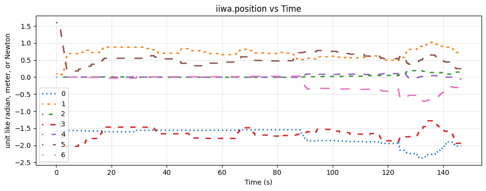

```
The gripper has one commanded postion: opening width.
```

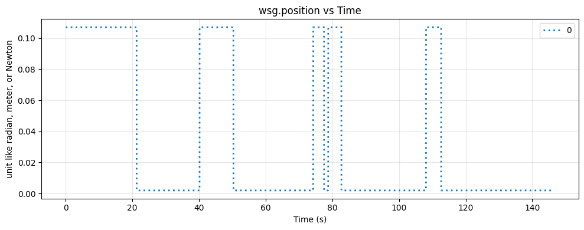

```python
def PlotState(state_name, logs, range_components = []):
  title = state_name + " vs Time"
  log = logs[state_name]
  times = log.sample_times()
  if range_components == []:
    range_components = range(0, len(log.data()))

  plt.figure(figsize=(10,4))

  for i in range_components:
    data = log.data()[i]
    plt.plot(times, data, linestyle=(i, (i+1, i+2)), linewidth=2, label=i)

  plt.xlabel("Time (s)")
  plt.ylabel("unit like radian, meter, or Newton")
  plt.title(title)
  plt.grid(True, alpha=0.3)
  plt.legend()
  plt.tight_layout()
  plt.show()

print(control_outputs)

print("The iiwa arm has seven joints.")
PlotState("iiwa.position", control_logs)

print("The gripper has one commanded postion: opening width.")
PlotState("wsg.position", control_logs)
```

# Plot RobotDiagram output: measured position and state

```
['iiwa.position_measured', 'wsg.state_measured', 'peg_state']

Measured gripper position (meter)
```

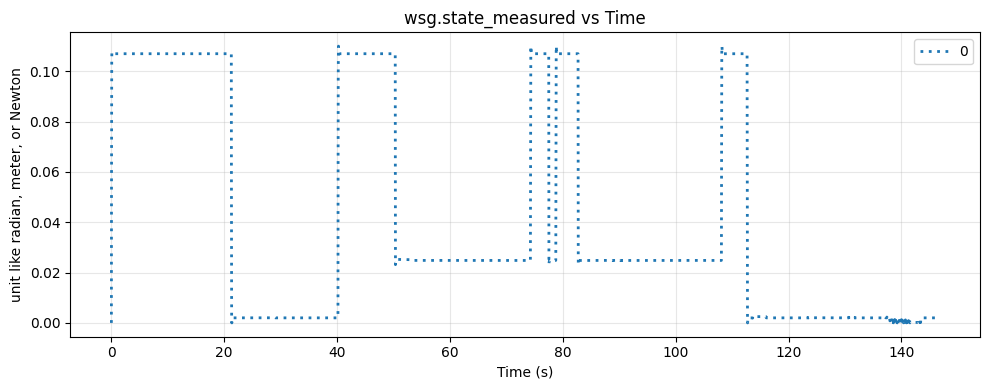

```
Measured gripper speed (meter/second)
```

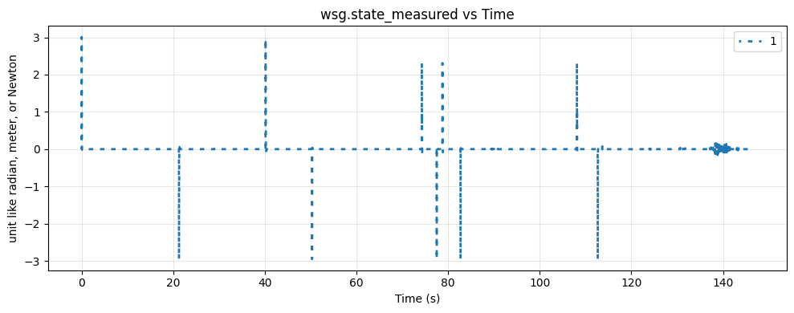

```
Seven joint angles (radian)
```

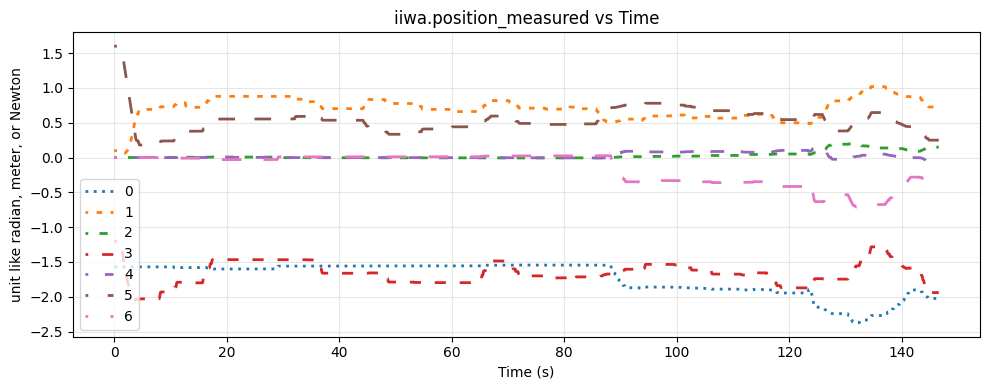

```python
# Names are in `station_outputs`.
# The corresponding logs are in `station_logs`.
print(station_outputs)
print()

# wsg.state_measured has two components: position and speed.
# They have different units.
print("Measured gripper position (meter)")
PlotState("wsg.state_measured", station_logs, range(0,1))
print("Measured gripper speed (meter/second)")
PlotState("wsg.state_measured", station_logs, range(1,2))

# iiwa.position_measured has seven components: 7 joint angles.
print("Seven joint angles (radian)")
PlotState("iiwa.position_measured", station_logs)
```

```
peg_state has 13 components (orientation quarternian(4), position(3), and d/dt(6)).
However, we plot only the orientation and position.
```

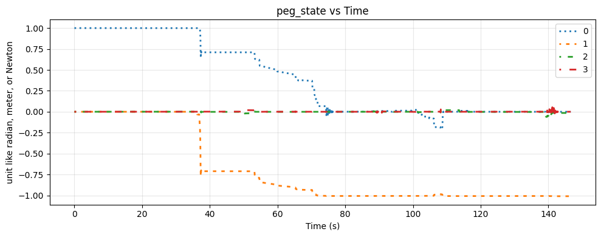

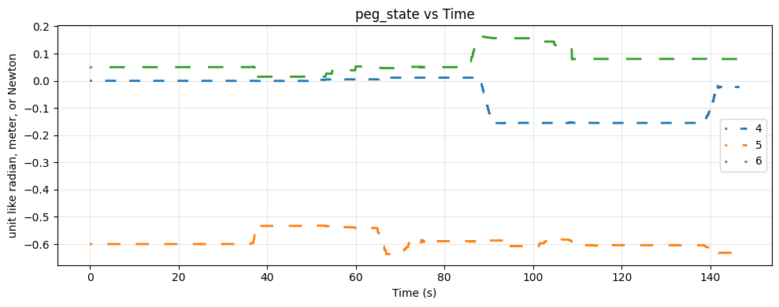

```python
def PlotPegState():
  n = len(station_logs["peg_state"].data())
  print(f"peg_state has {n} components (orientation quarternian(4), position(3), and d/dt(6)).\n" +
         "However, we plot only the orientation and position.")

  # Orientation
  PlotState("peg_state", station_logs, range(0,4))

  # Position
  PlotState("peg_state", station_logs, range(4,7))


# Initially X_WPeg = orientation quaternion(1,0,0,0) and translation(0, -0.6, 0.05)
PlotPegState()
```

## Plot contact wrench

```
------------------------------------------------------------------------------------
PlotContactWrench()
The first three components of the contact wrench is the torque (Newton * meter).
```

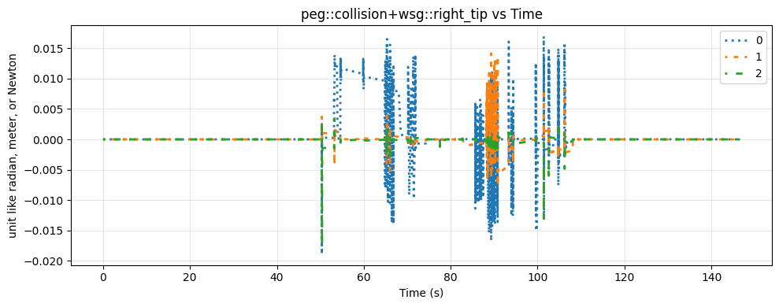

```
The last three components of the contact wrench is the force (Newton).
```

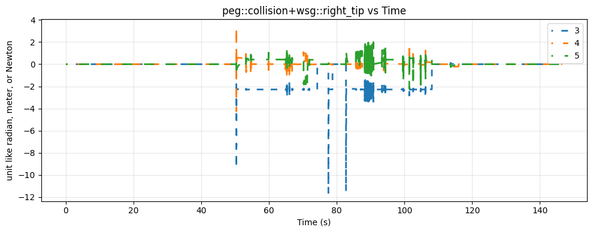

```python
def PlotContactWrench(pair):
  print("------------------------------------------------------------------------------------")
  print("PlotContactWrench()")
  print("The first three components of the contact wrench is the torque (Newton * meter).")
  PlotState(pair[0] + "+" + pair[1], contact_logs, range(0,3))

  print("The last three components of the contact wrench is the force (Newton).")
  PlotState(pair[0] + "+" + pair[1], contact_logs, range(3,6))

PlotContactWrench(contact_outputs[0])
```

```
------------------------------------------------------------------------------------
PlotContactWrench()
The first three components of the contact wrench is the torque (Newton * meter).
```

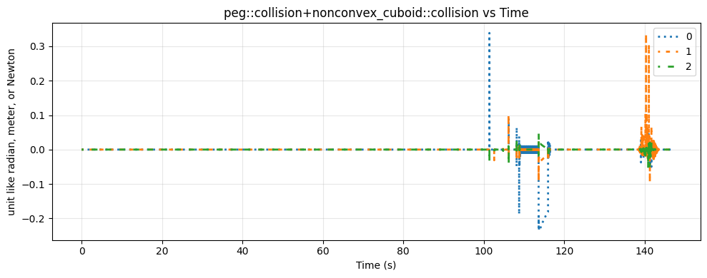

```
The last three components of the contact wrench is the force (Newton).
```

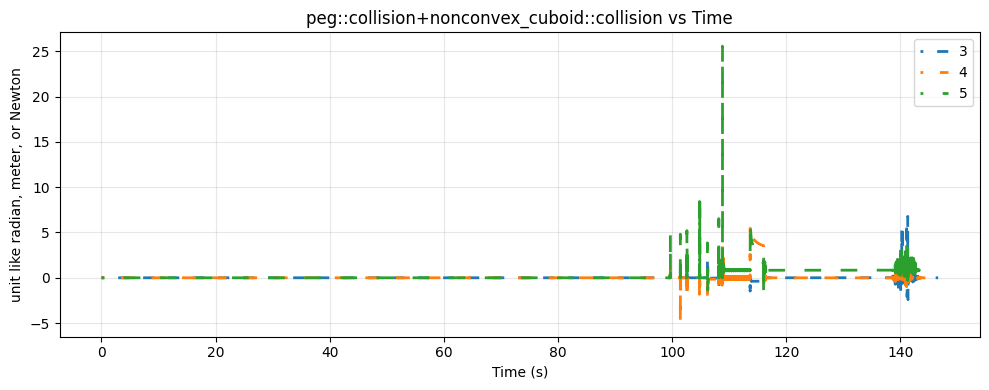

```python
PlotContactWrench(contact_outputs[1])
```

```
------------------------------------------------------------------------------------
PlotContactWrench()
The first three components of the contact wrench is the torque (Newton * meter).
```

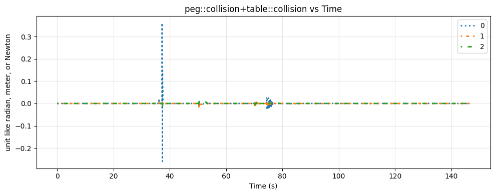

```
The last three components of the contact wrench is the force (Newton).
```

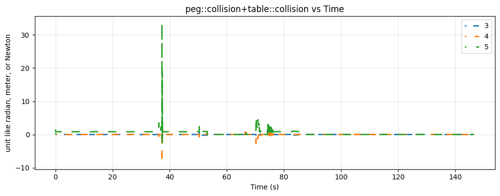

```python
PlotContactWrench(contact_outputs[2])
```

```python
print("T h a n k   Y o u !")
```

```
T h a n k   Y o u !
```